# Homework4_Peters_Jake

## Homework

Let’s return to the brca dataset. Now, we will use the predictors: mean radius and mean texture.

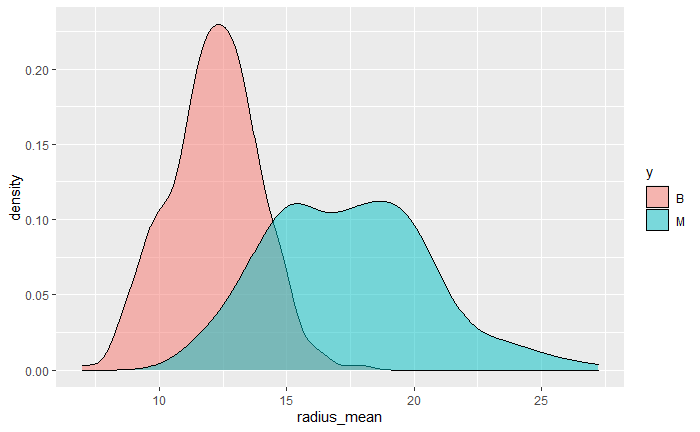

```r
data(brca)
brca_data <- data.frame(brca$x) %>%
  select(radius_mean, texture_mean) %>%
  data.frame(y = brca$y)

set.seed(42)
test_index <- createDataPartition(brca_data$y, p = 0.25, list = FALSE)
test_brca <- brca_data[test_index,]
train_brca <- brca_data[-test_index,]

ggplot(train_brca)+
  geom_density(mapping = aes(x =  radius_mean, fill = y), alpha = 0.5)
```

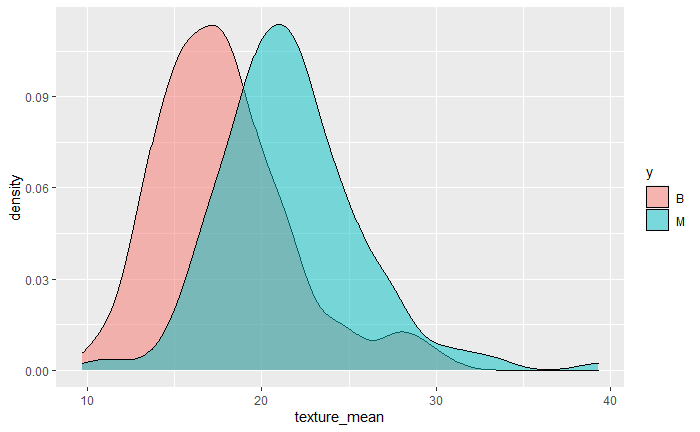

```r
ggplot(train_brca)+
  geom_density(mapping = aes(x =  texture_mean, fill = y), alpha = 0.5)
```

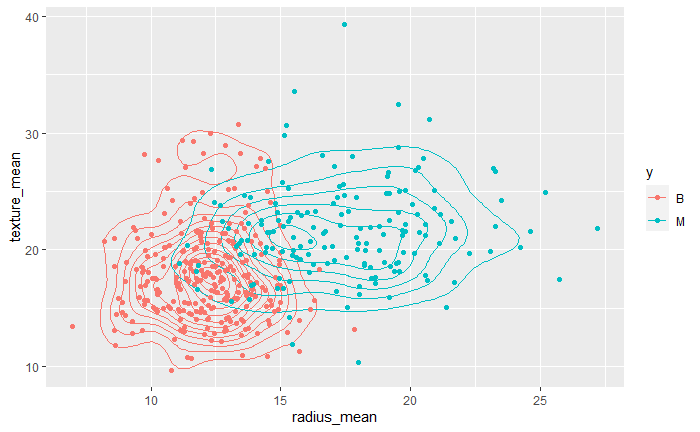

```r
ggplot(train_brca)+
  geom_density2d(mapping = aes(x = radius_mean, y = texture_mean, color = y))+
  geom_point(mapping = aes(x = radius_mean, y = texture_mean, color = y))
```

```r
train_brca
```

|  | radius_mean | texture_mean | y |
| --- | --- | --- | --- |
| 2 | 13.080 | 15.71 | B |
| 6 | 12.050 | 14.63 | B |
| 7 | 13.490 | 22.30 | B |
| 8 | 11.760 | 21.60 | B |
| 9 | 13.640 | 16.34 | B |
| 10 | 11.940 | 18.24 | B |
| 11 | 11.520 | 18.75 | B |
| 12 | 13.050 | 19.31 | B |
| 13 | 8.618 | 11.79 | B |
| 14 | 10.170 | 14.88 | B |

[output cut: 416 more lines]

### Problem 1

Create a kNN model using k = 1 neighbor to predict whether the mass is malignant or benign. Visualize the model results on the test set using color for the actual class and shape for whether the point is correctly. Also, compute the confusion matrix (treating malignant as the positive class).

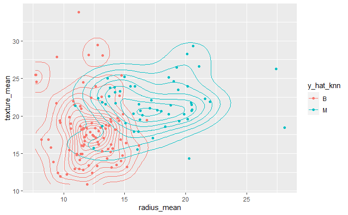

```r
## Your code goes here.
model_knn <- train(y ~ .,
                   data = train_brca,
                   method = "knn",
                   tuneGrid = data.frame(k=1))
y_hat_knn <- predict(model_knn, newdata = test_brca[,1:2])


ggplot(test_brca)+
  geom_density2d(mapping = aes(x = radius_mean, y = texture_mean, color = y_hat_knn))+
  geom_point(mapping = aes(x = radius_mean, y = texture_mean, color = y))
```

```r
confusionMatrix(data = y_hat_knn, reference = factor(test_brca$y), positive = "M")
```

```
Confusion Matrix and Statistics

          Reference
Prediction  B  M
         B 78  8
         M 12 45

               Accuracy : 0.8601
                 95% CI : (0.7923, 0.9124)
    No Information Rate : 0.6294
    P-Value [Acc > NIR] : 7.858e-10

                  Kappa : 0.7048

 Mcnemar's Test P-Value : 0.5023

            Sensitivity : 0.8491
            Specificity : 0.8667
         Pos Pred Value : 0.7895
         Neg Pred Value : 0.9070
             Prevalence : 0.3706
         Detection Rate : 0.3147
   Detection Prevalence : 0.3986
      Balanced Accuracy : 0.8579

       'Positive' Class : M
```

### Problem 2

For the k=1 model, create a probability map for the probability that the mass is malignant. The command `brca_grid <- expand.grid(radius_mean = seq(7,30,0.1), texture_mean = seq(10,35,0.1))` will create a grid of radius and texture values that you can use as new data to predict probabilities. Since k=1, what values can the predicted probability take?

```r
## Your code goes here.
brca_grid <- expand.grid(radius_mean = seq(7,30,0.1), texture_mean = seq(10,35,0.1))
y_hat_knn_prob <- predict(model_knn, newdata = brca_grid[,1:2],type = "prob")
y_hat_knn_prob
```

| B | M |
| --- | --- |
| 1 | 0 |
| 1 | 0 |
| 1 | 0 |
| 1 | 0 |
| 1 | 0 |
| 1 | 0 |
| 1 | 0 |
| 1 | 0 |
| 1 | 0 |
| 1 | 0 |

[output cut: 990 more lines]

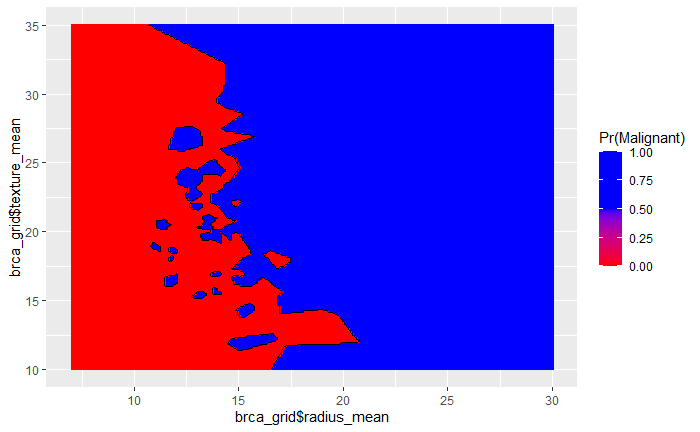

```r
ggplot(y_hat_knn_prob, mapping = aes(x = brca_grid$radius_mean, y = brca_grid$texture_mean, z = M, fill = M)) +
  geom_raster()+
  scale_fill_gradientn(colors=c("red","blue","blue"), name = "Pr(Malignant)") +
  stat_contour(breaks=c(0.5),color="black")
```

The values are either 1 or 0 because the nearest neighbor is all-or-nothing, 100% malignant or 100% benign.

### Problem 3

Create a kNN model using k = 11 neighbors to predict whether the mass is malignant or benign. Visualize the model results on the test set using color for the actual class and shape for whether the point is correctly. Also, compute the confusion matrix (treating malignant as the positive class).

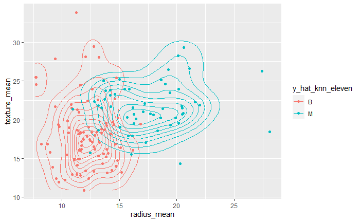

```r
## Your code goes here.
model_knn_eleven <- train(y ~ .,
                   data = train_brca,
                   method = "knn",
                   tuneGrid = data.frame(k=11))
y_hat_knn_eleven <- predict(model_knn_eleven, newdata = test_brca[,1:2])


ggplot(test_brca)+
  geom_density2d(mapping = aes(x = radius_mean, y = texture_mean, color = y_hat_knn_eleven))+
  geom_point(mapping = aes(x = radius_mean, y = texture_mean, color = y))
```

```r
confusionMatrix(data = y_hat_knn_eleven, reference = factor(test_brca$y), positive = "M")
```

```
Confusion Matrix and Statistics

          Reference
Prediction  B  M
         B 85 10
         M  5 43

               Accuracy : 0.8951
                 95% CI : (0.8329, 0.9401)
    No Information Rate : 0.6294
    P-Value [Acc > NIR] : 5.903e-13

                  Kappa : 0.7707

 Mcnemar's Test P-Value : 0.3017

            Sensitivity : 0.8113
            Specificity : 0.9444
         Pos Pred Value : 0.8958
         Neg Pred Value : 0.8947
             Prevalence : 0.3706
         Detection Rate : 0.3007
   Detection Prevalence : 0.3357
      Balanced Accuracy : 0.8779

       'Positive' Class : M
```

### Problem 4

For the k=11 model, create a probability map for the probability that the mass is malignant. You can reuse the `brca_grid` from problem 2. Since k=11, what values can the predicted probability take?

```r
## Your code goes here.
brca_grid <- expand.grid(radius_mean = seq(7,30,0.1), texture_mean = seq(10,35,0.1))
y_hat_knn_eleven_prob <- predict(model_knn_eleven, newdata = brca_grid[,1:2],type = "prob")
y_hat_knn_eleven_prob
```

| B | M |
| --- | --- |
| 1.00000000 | 0.00000000 |
| 1.00000000 | 0.00000000 |
| 1.00000000 | 0.00000000 |
| 1.00000000 | 0.00000000 |
| 1.00000000 | 0.00000000 |
| 1.00000000 | 0.00000000 |
| 1.00000000 | 0.00000000 |
| 1.00000000 | 0.00000000 |
| 1.00000000 | 0.00000000 |
| 1.00000000 | 0.00000000 |

[output cut: 990 more lines]

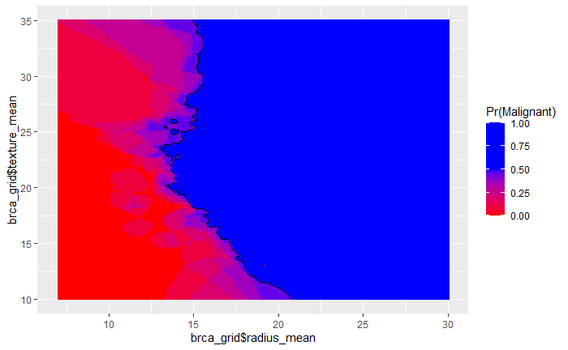

```r
ggplot(y_hat_knn_eleven_prob, mapping = aes(x = brca_grid$radius_mean, y = brca_grid$texture_mean, z = M, fill = M)) +
  geom_raster()+
  scale_fill_gradientn(colors=c("red","blue","blue"), name = "Pr(Malignant)") +
  stat_contour(breaks=c(0.5),color="black")
```

The values can be anywhere from 0/11, 1/11, 2/11, … , 10/11, 11/11. for B and then 1 - prob(B) for M.

### Problem 5

Use 10-fold cross-validation (with Kappa as the metric) to select the best value for the number of neighbors (use k = seq(1,41,2)). What value of k gives the best Kappa?

```r
## Your code goes here.
control = trainControl(method = "cv", number = 10)
model_knn_cv <- train(y ~ .,
                   data = train_brca,
                   method = "knn",
                   tuneGrid = data.frame(k=seq(1,41,2)),
                   trControl = control,
                   metric = "Kappa")
model_knn_cv
```

```
k-Nearest Neighbors

426 samples
  2 predictor
  2 classes: 'B', 'M'

No pre-processing
Resampling: Cross-Validated (10 fold)
Summary of sample sizes: 383, 383, 384, 383, 383, 384, ...
Resampling results across tuning parameters:

  k   Accuracy   Kappa
   1  0.8732004  0.7287907
   3  0.8850498  0.7507340
   5  0.8736434  0.7233730
   7  0.8876523  0.7524293
   9  0.8852713  0.7463099
  11  0.8946290  0.7680285
  13  0.8898671  0.7583851
  15  0.8852713  0.7484018
  17  0.8899225  0.7583343
  19  0.8899779  0.7578522
  21  0.8899779  0.7570666
  23  0.8946290  0.7675179
  25  0.8993355  0.7794691
  27  0.8969546  0.7734226
  29  0.8993355  0.7786835
  31  0.9017165  0.7841410
  33  0.9040421  0.7890379
  35  0.9064230  0.7939061
  37  0.9087486  0.7989089
  39  0.8946290  0.7693557
  41  0.9040975  0.7887320

Kappa was used to select the optimal model using the largest value.
The final value used for the model was k = 37.
```

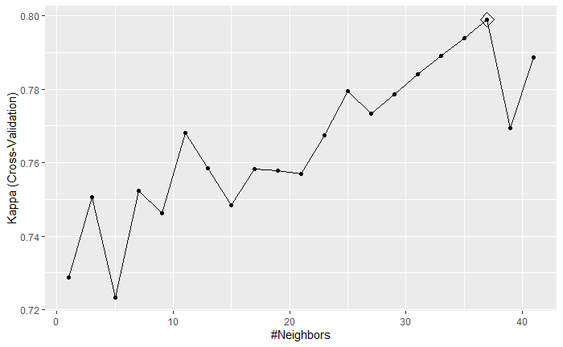

```r
ggplot(model_knn_cv, highlight = TRUE)
```

A k of 37 gives the best value of Kappa at .799.

### Problem 6

Visualize the model results (using the best k) on the test set using color for the actual class and shape for whether the point is correctly. Also, compute the confusion matrix (treating malignant as the positive class).

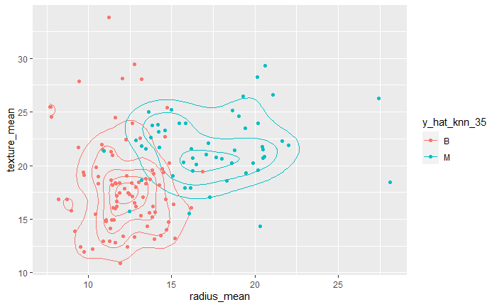

```r
## Your code goes here.
model_knn_35 <- train(y ~ .,
                   data = train_brca,
                   method = "knn",
                   tuneGrid = data.frame(k=37))
y_hat_knn_35 <- predict(model_knn_35, newdata = test_brca[,1:2])


ggplot(test_brca)+
  geom_density2d(mapping = aes(x = radius_mean, y = texture_mean, color = y_hat_knn_35))+
  geom_point(mapping = aes(x = radius_mean, y = texture_mean, color = y))
```

```r
confusionMatrix(data = y_hat_knn_35, reference = factor(test_brca$y), positive = "M")
```

```
Confusion Matrix and Statistics

          Reference
Prediction  B  M
         B 85  7
         M  5 46

               Accuracy : 0.9161
                 95% CI : (0.858, 0.9559)
    No Information Rate : 0.6294
    P-Value [Acc > NIR] : 3.414e-15

                  Kappa : 0.8187

 Mcnemar's Test P-Value : 0.7728

            Sensitivity : 0.8679
            Specificity : 0.9444
         Pos Pred Value : 0.9020
         Neg Pred Value : 0.9239
             Prevalence : 0.3706
         Detection Rate : 0.3217
   Detection Prevalence : 0.3566
      Balanced Accuracy : 0.9062

       'Positive' Class : M
```

### Problem 7

For the best k model, create a probability map for the probability that the mass is malignant.

```r
## Your code goes here.
brca_grid <- expand.grid(radius_mean = seq(7,30,0.1), texture_mean = seq(10,35,0.1))
y_hat_knn_35_prob <- predict(model_knn_35, newdata = brca_grid[,1:2],type = "prob")
y_hat_knn_35_prob
```

| B | M |
| --- | --- |
| 1.00000000 | 0.00000000 |
| 1.00000000 | 0.00000000 |
| 1.00000000 | 0.00000000 |
| 1.00000000 | 0.00000000 |
| 1.00000000 | 0.00000000 |
| 1.00000000 | 0.00000000 |
| 1.00000000 | 0.00000000 |
| 1.00000000 | 0.00000000 |
| 1.00000000 | 0.00000000 |
| 1.00000000 | 0.00000000 |

[output cut: 990 more lines]

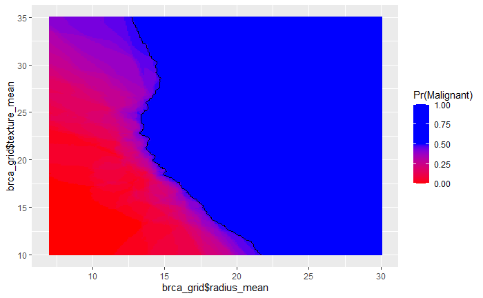

```r
ggplot(y_hat_knn_35_prob, mapping = aes(x = brca_grid$radius_mean, y = brca_grid$texture_mean, z = M, fill = M)) +
  geom_raster()+
  scale_fill_gradientn(colors=c("red","blue","blue"), name = "Pr(Malignant)") +
  stat_contour(breaks=c(0.5),color="black")
```

## Homework Part 2

Create a kNN model for sale price using latitude, longitude, total square footage, and style. Center and scale latitude, longitude, and total square footage. Create dummy variables for style. Use cross-validation to select k from 1 to 81 (by 4).

```r
FM_housing = read_csv(file = "https://raw.githubusercontent.com/gmtanner-cord/DATA318/master/Original%20Data/FM_housing.csv",
                      col_types = cols(City = "f",
                                       `State/Province` = "f",
                                       `Postal Code` = "f",
                                       `Style` = "f",
                                       `Garage Type` = "f",
                                       `Flood Plain` = "f",
                                       `Master Bedroom Main Flr` ="f",
                                       `Laundry Location` = "f",
                                       `High School` = "f")) %>%
  filter(!(`High School` %in% c("Central Cass","Barnesville"))) %>%
  mutate(`High School` = fct_drop(`High School`))

set.seed(42) # This is for reproducibility, so that everyone gets the same answers.
test_index <- createDataPartition(FM_housing$`Sold Price`, p = 0.20, list = FALSE)
test_set <- FM_housing[test_index,]
train_set <- FM_housing[-test_index,]
```

```r
## Your code here.
dummies <- dummyVars(~ `Style`, data = train_set)
StyleDummies_train <- predict(dummies, newdata = train_set)
StyleDummies_test <- predict(dummies, newdata = test_set)
head(StyleDummies_train)
```

```
  Style.1 Story Style.Bi Level Style.1 1/2 Stor Style.2 Story Style.3 Level Style.4 Level Style.3 Story Style.None
1             1              0                0             0             0             0             0          0
2             0              1                0             0             0             0             0          0
3             1              0                0             0             0             0             0          0
4             0              1                0             0             0             0             0          0
5             1              0                0             0             0             0             0          0
6             0              0                1             0             0             0             0          0
```

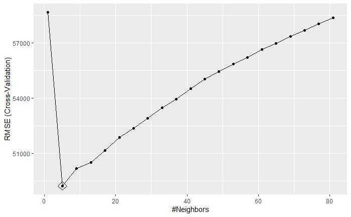

```r
train_ready <- train_set %>%
  select(`Sold Price`, `Total SqFt.`,`Geo Lat`, `Geo Lon`) %>%
  cbind(StyleDummies_train)
test_ready <- test_set %>%
  select(`Sold Price`, `Total SqFt.`,`Geo Lat`, `Geo Lon`) %>%
  cbind(StyleDummies_test)

control <- trainControl(method = "cv", number = 10)
model_knn_cv <- train(`Sold Price` ~ .,
                   data = train_ready,
                   method = "knn",
                   tuneGrid = data.frame(k=seq(1,81,4)),
                   trControl = control,
                   preProcess = c("center","scale"))
ggplot(model_knn_cv, highlight = TRUE)
```

```r
model_knn_cv
```

```
k-Nearest Neighbors

4940 samples
  11 predictor

Pre-processing: centered (11), scaled (11)
Resampling: Cross-Validated (10 fold)
Summary of sample sizes: 4445, 4445, 4446, 4447, 4446, 4447, ...
Resampling results across tuning parameters:

  k   RMSE      Rsquared   MAE
   1  58647.62  0.7462969  34478.62
   5  49226.90  0.8093901  30052.16
   9  50175.34  0.8031184  30574.74
  13  50498.90  0.8018749  31120.95
  17  51143.97  0.7983765  31432.15
  21  51872.08  0.7934837  31871.15
  25  52341.06  0.7905366  32213.13
  29  52889.33  0.7869358  32463.21
  33  53480.87  0.7829416  32797.31
  37  53938.46  0.7800871  33173.14
  41  54494.12  0.7761324  33583.95
  45  55035.61  0.7720074  33958.16
  49  55425.12  0.7692774  34181.04
  53  55831.84  0.7665132  34416.99
  57  56198.27  0.7642201  34626.35
  61  56623.21  0.7610976  34933.25
  65  56966.71  0.7587851  35163.93
  69  57328.33  0.7565071  35412.14
  73  57668.20  0.7540908  35638.25
  77  58020.82  0.7517033  35875.68
  81  58361.25  0.7491568  36134.48

RMSE was used to select the optimal model using the smallest value.
The final value used for the model was k = 5.
```

```r
y_hat_knn_cv <- predict(model_knn_cv, newdata = test_ready)
postResample(y_hat_knn_cv,test_ready$`Sold Price`)
```

```
        RMSE     Rsquared          MAE
4.760528e+04 7.943442e-01 2.949018e+04
```